# Dragon Master Project

**Main goal:** Find the best country/region on earth according to a living quality index based on:  
1. Hazard frequency and distribution;  
2. Air pollution;  
3. GDP;  
4. Average year NDVI.

**Warning:** Running the entire script takes about 2 hours of computation time in the 2 core virtual machine we used. We highly recommend using the terminal.

## Setup

Our project core is located at main.R file. First, we start by setting some environment settings, including he installation of necessary libraries and the import of such libraries. We also source the sub-scripts in the setup section.

```r
knitr::opts_chunk$set(warning = FALSE, message = FALSE)
```

## Downloads

For downloading the necessary datasets, we used two bash scripts called from the main script and a simple download.file function call.

For the purpose of the SEDAC data downloaded we used the following wget command.

```r
# Example for Drought Hazard dataset
wget -L --user=rodrigoalmeida94 --password=*RmA20071994**** --load-cookies ~/.cookies --save-cookies ~/.cookies --no-directories http://sedac.ciesin.columbia.edu/downloads/data/ndh/ndh-drought-hazard-frequency-distribution/gddrg.zip
# Unzips and places files in the right place
unzip gddrg.zip -d ../data/
rm gddrg.zip
mv ../data/gddrg/gddrg.asc ../data/haz_drought.asc
mv ../data/gddrg/gddrg.prj ../data/haz_drought.prj
rm -r ../data/gddrg
```

For the MODIS NDVI product, we made a for loop that goes through every folder in the DAAC for 2016 and downloads the respective file (0.05 degrees resolution).

```r
for i in 01 02 03 04 05 06 07 08 09 10 11 12;
do wget -L --user=rodrigoalmeida94 --password=**** --load-cookies ~/.cookies --save-cookies ~/.cookies -r --no-parent -A '*.hdf' --no-directories -P ../data/http://e4ftl01.cr.usgs.gov/MOLT/MOD13C2.006/2016.$i.01/
done
```

The GECON datasets were available in SEDAC as well, but unfortunately the data had some issues, so we decided to make the raster layer ourselfs from the XLS file provided in the project website.

## Read files

The process of reading the files into memory is quite straighforward:  
1. Loading all the hazard files with the correct name using a for loop;  
2. Loading the NDVI monthly data, and passing it to the annual_mean function, that returns the annual mean;  
3. Loading the PM2.5 dataset into memory; 4. Creating the GECON data with the XLS file into two rasters GECON PPP (Purchasing Power Parity) and GECON MER (Market Exchange Rate).

The annual mean function for the NDVI takes the month dataset, cleans the data according to the reliability layer that is provided with the MODIS NDVI product and calculates the mean.

The creation of the GECON dataset from the XLS file was a bit trickier than expected, since the gridded takes the coordinates as the center of the cell coordinates, and in this case it was the coordinates of the corners of the cell. Because of that it was necessary to add 1 degree to the existing coordinates to correct for that.

## Files information

In order to obtain an overview of the downloaded files, we created a function to report all attributes of the data sets in a data frame format.

We call that function from the main and store some important information for the file preprocessing like the maximum resolution and the appropriate CRS.

Below you can see a showcase of the downloaded data, including the result of the data_summary function.

```r
raster::plot(haz_cyclone, main = 'Cyclone Hazard')
plot(haz_drought, main = 'Drought Hazard')
plot(haz_earthquake, main = 'Earthquake Hazard')
plot(haz_flood, main = 'Flood Hazard')
plot(haz_landslide, main = 'Landslide Hazard')
plot(haz_volcano, main = 'Volcano Hazard')
plot(annualpm25, main = 'Annual PM2.5')
plot(gecon_ppp, main = 'GDP per cell PPP')
plot(ndvi_mean, main = '2016 NDVI montly mean')

print(data_summary)
```

[output not shown]

## Files pre-processing

This part of our script uses the data gathered at with the data summary function to resample and reproject the necessary datasets to the same grid and CRS. This is time consuming step since we are handling worldwide datasets.

We also read the reprojected files into memory, add some aditional information to the datasets (units) and use the rworldmap library to get a world continental boundary.

## Index calculation

```r
plot(haz_comp, main = 'Hazards Component')
```

[output not shown]

For a more efficient visualization of the data, we multiplied the resulting index by 100 and saved it into a TIF file with a INT2S data type. In this instance, we have predefined five weights combinations:  
1. Same weight - $H_w,PM2.5_w,NDVI_w,GDP_w = (1,1,1,1)$;  
2. Greenest - $H_w,PM2.5_w,NDVI_w,GDP_w = (0.5,0.5,1,0.5)$;  
3. Richest - $H_w,PM2.5_w,NDVI_w,GDP_w = (0.5,0.5,0.5,1)$;  
4. Less hazards - $H_w,PM2.5_w,NDVI_w,GDP_w = (1,0.5,0.5,0.5)$;  
5. Less polution - $H_w,PM2.5_w,NDVI_w,GDP_w = (0.5,1,0.5,0.5)$.

## Visualization

For visuzalization of the index results we used Leaflet to create an html file that allows the user to select which combination of weights is prefered.

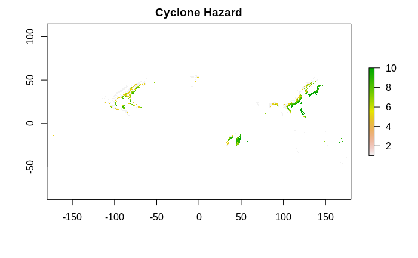

```r
plot(haz_cyclone, main = 'Cyclone Hazard')
```

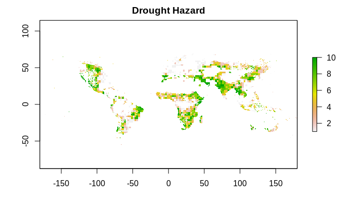

```r
plot(haz_drought, main = 'Drought Hazard')
```

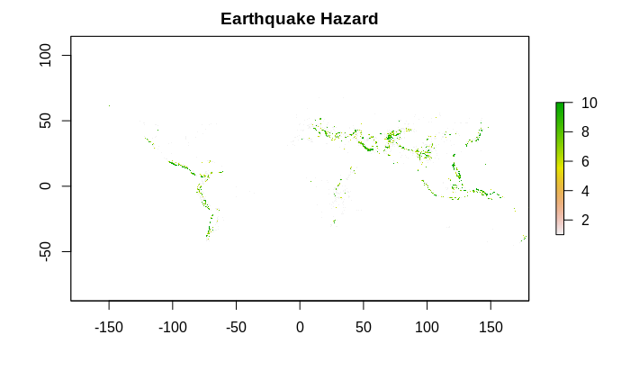

```r
plot(haz_earthquake, main = 'Earthquake Hazard')
```

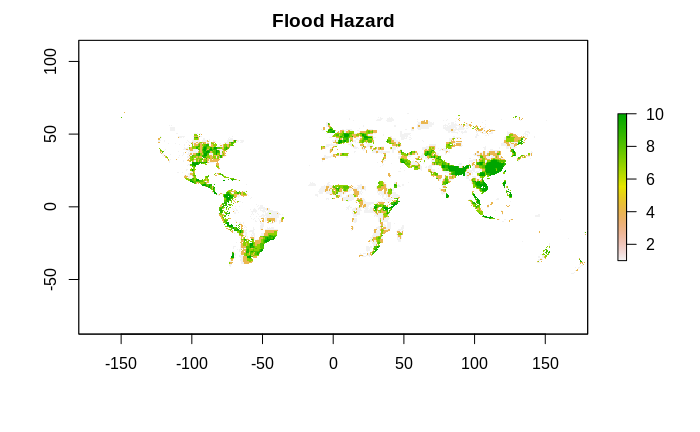

```r
plot(haz_flood, main = 'Flood Hazard')
```

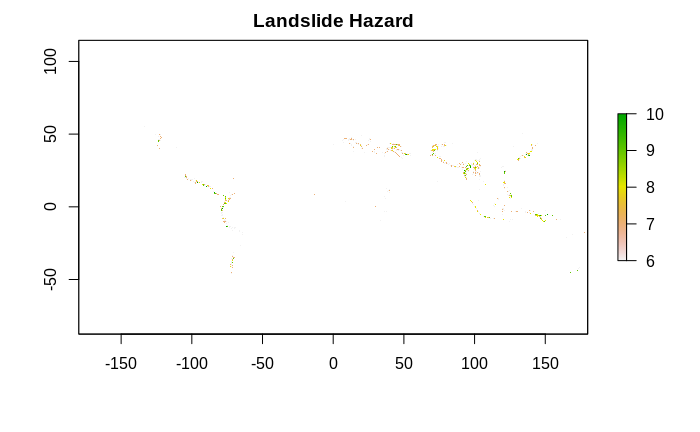

```r
plot(haz_landslide, main = 'Landslide Hazard')
```

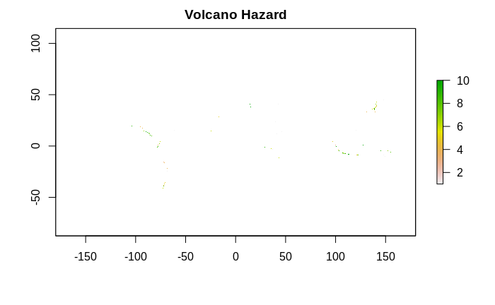

```r
plot(haz_volcano, main = 'Volcano Hazard')
```

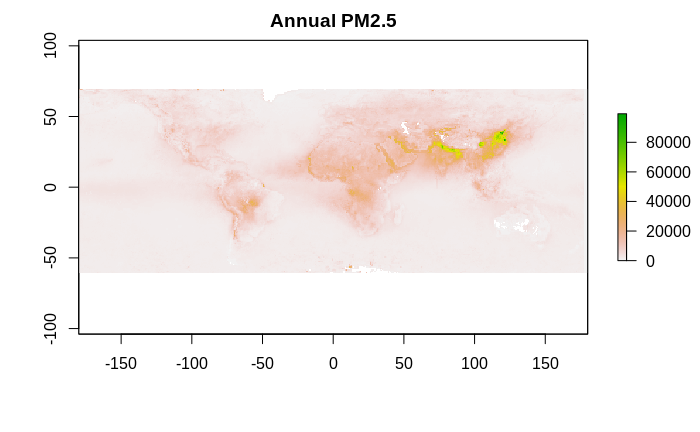

```r
plot(annualpm25, main = 'Annual PM2.5')
```

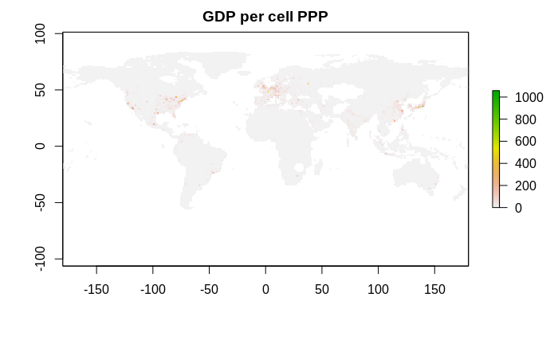

```r
plot(gecon_ppp, main = 'GDP per cell PPP')
```

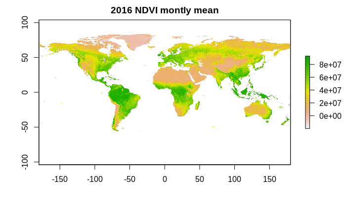

```r
plot(ndvi_mean, main = '2016 NDVI montly mean')
```

```r
print(data_summary)
```

```
               raster class         xmin      xmax     ymin      ymax
annualpm25     ?      "RasterLayer" -180      180      -90       90
gecon_mer      ?      "RasterLayer" -180      180      -89       84
gecon_ppp      ?      "RasterLayer" -180      180      -89       84
haz_cyclone    ?      "RasterLayer" -179.9984 179.9977 -58.01507 85.01593
haz_drought    ?      "RasterLayer" -180      180      -58       85
haz_earthquake ?      "RasterLayer" -180      180      -58.01507 84.98493
haz_flood      ?      "RasterLayer" -180      180      -58.01507 84.98493
haz_landslide  ?      "RasterLayer" -180      180      -58       85
haz_volcano    ?      "RasterLayer" -180      180      -58.01507 84.98493
ndvi_mean      ?      "RasterLayer" -180      180      -90       90
               projargs                                                          resx       resy       data_min
annualpm25     "+proj=longlat +datum=WGS84 +no_defs +ellps=WGS84 +towgs84=0,0,0" 0.5        0.5        0
gecon_mer      "+proj=longlat +datum=WGS84 +no_defs +ellps=WGS84 +towgs84=0,0,0" 1          1          0
gecon_ppp      "+proj=longlat +datum=WGS84 +no_defs +ellps=WGS84 +towgs84=0,0,0" 1          1          0
haz_cyclone    "+proj=longlat +datum=WGS84 +no_defs +ellps=WGS84 +towgs84=0,0,0" 0.0417     0.0417     -2147483648
haz_drought    "+proj=longlat +datum=WGS84 +no_defs +ellps=WGS84 +towgs84=0,0,0" 0.04166667 0.04166667 -2147483648
haz_earthquake "+proj=longlat +datum=WGS84 +no_defs +ellps=WGS84 +towgs84=0,0,0" 0.04166667 0.04166667 -2147483648
haz_flood      "+proj=longlat +datum=WGS84 +no_defs +ellps=WGS84 +towgs84=0,0,0" 0.04166667 0.04166667 -2147483648
haz_landslide  "+proj=longlat +datum=WGS84 +no_defs +ellps=WGS84 +towgs84=0,0,0" 0.04166667 0.04166667 -2147483648
haz_volcano    "+proj=longlat +datum=WGS84 +no_defs +ellps=WGS84 +towgs84=0,0,0" 0.04166667 0.04166667 -2147483648
ndvi_mean      "+proj=longlat +ellps=clrk66 +no_defs"                            0.05       0.05       -2e+07
               data_max
annualpm25     99284
gecon_mer      1564.419
gecon_ppp      1058.671
haz_cyclone    2147483647
haz_drought    2147483647
haz_earthquake 2147483647
haz_flood      2147483647
haz_landslide  2147483647
haz_volcano    2147483647
ndvi_mean      99800000
```

[figure not shown]

```r
plot(haz_comp, main = 'Hazards Component')
```